# Lab 9 SOLUTION

Monash University, Econ & Bus Stat, ETC3250/5250

prepared by Professor Di Cook

Materials for Week 9

# Class discussion

Chapter 6, exercise 1.

**(a) best subset**

**(b) don’t know - it could be any**

**(c) i.-ii. True iii.-v. False**

# Theory

Chapter 6, exercise 7a. Take a look at the solution at http://www.jeffreylimbacher.me/ISLR-exercises/chap6.html

1. What’s a density function, and what is it used for? **Density functions describe the probability of ranges of values to occur.**
2. What’s a likelihood function (assuming a sample of data), and what is it used for? **Likelihoood functions are used to estimate model parameters that best fit a sample.**
3. If $\epsilon_i \sim N(0, \sigma^2)$ write down the density function, from the model $y_i = \beta_0 + \sum_{j=1}^{p} x_{ij}\beta_j + \epsilon_i$. **Normal density function, sdone this before.**
4. Given c, what distribution does $y_i|x_i$ have? Write it down.
5. Using your density function for $y_i$ write down the likelihood function. **As at http://www.jeffreylimbacher.me/ISLR-exercises/chap6.html**
6. What values for $\beta_j$ maximize this likelihood? **It should be the least squares estimates, or very close to these, since the likelihood is doing much the same thing, comparing the observed with expected.**
7. Make a simple example: set $p=1, \beta_0, \beta_2, \sigma=1$, as set in the code below, and the sample using

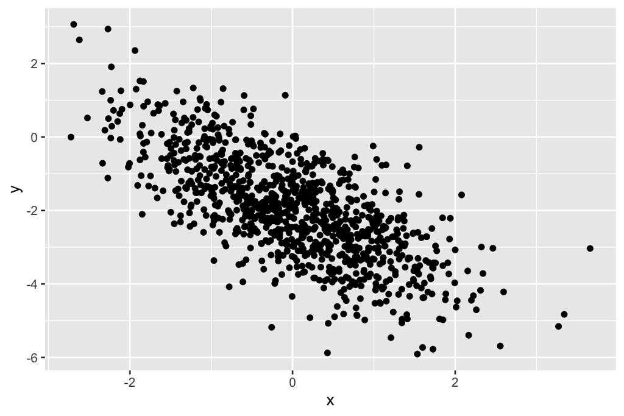

```r
library(tidyverse)
set.seed(20200515)
n <- 1000
b <- c(-2,-1)
x <- rnorm(n)
y <- b[1]+b[2]*x+rnorm(n)
df <- data.frame(x,y)
ggplot(df, aes(x, y)) + geom_point()
```

What would you expect the values for $\beta_0, \beta_1$ be (or close to) from maximum likelihood? **The values should be close to the parameters used for the simulated data.**

What are the least squares estimates for these quantities? -1.9714747, -0.9965573

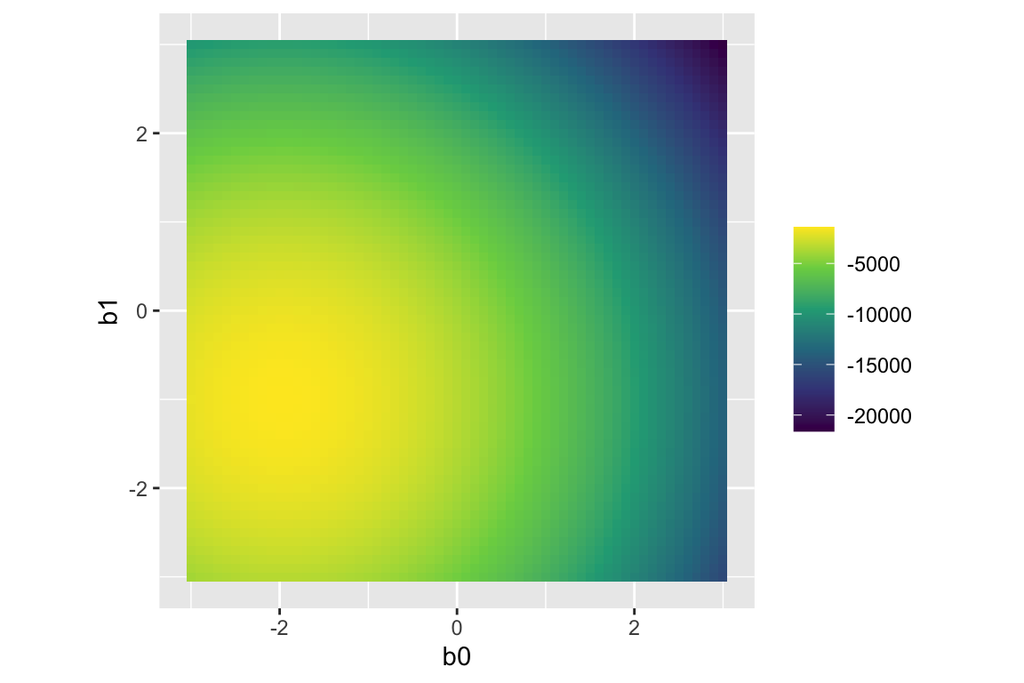

```
# Source: local data frame [1 x 3]
# Groups: <by row>
#
# # A tibble: 1 x 3
#      b0    b1      l
#   <dbl> <dbl>  <dbl>
# 1    -2    -1 -1411.
```

Change the values for $\beta_0, \beta_1$ (within the range of -3, 3 only) and the sample size, and examine the resulting maxima.

**The maximum value should follow aruond the simulation parameters.As sample size increases, it should get closer to the simulation parameters.**

# Exercises

This exercise is investigating neural network model fitting. A neural network model was fitted to the `wiggle.csv` using the `nnet` package in R, from many random starts, and using 2-4 nodes in the hidden layer. The best model is in the data object `nnet_best.rda`, and the full set of model fits are stored in `nnet_many.rda`. We are going investigate the best fit, and the complete set of fits. The data set is actually a test set, it was not used to fit the model, but it was simulated from the same process as the training set, which we don’t have.

## 1.

In this problem we will replicate what was done in Section 6, of https://vita.had.co.nz/papers/model-vis.pdf. Please read this first! It documents a struggle with getting the neural network to fit to a reasonably simple problem.

1. Read in the data, and make an appropriate plot, that communicates the relationship between the two variables and the two groups.

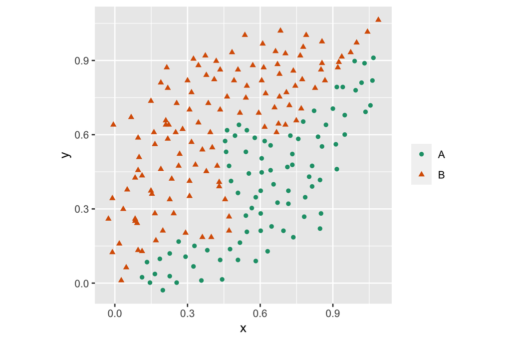

2. Read in the best model. Take a look at the object. There are three components: `hidden`, `output` and `nnet`. The best model uses $s=4$. The `nnet` component has the estimated model coefficients, fitted values and residuals. The `hidden` component has information related to the models used in the 4 nodes of the hidden layer, and the `output` has the same information for the second layer. These latter two contain a grid of values for the predictors, $x$, $y$ and the predicted values for each grid point.
   1. Plot the grid of predicted values for the second layer, using node 1. Overlay the data. How well has the model captured the class structure?

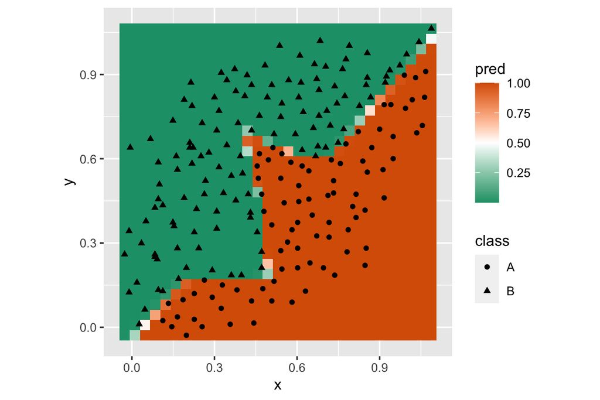

**The model does amazingly well to prediect this data.**

```
(ii) Plot the grid of predicted values for each node in the hidden layer, with the data overlaid. Explain how the models at each node would combine to make the final model predictions, which we have already seen are extremely good.
```

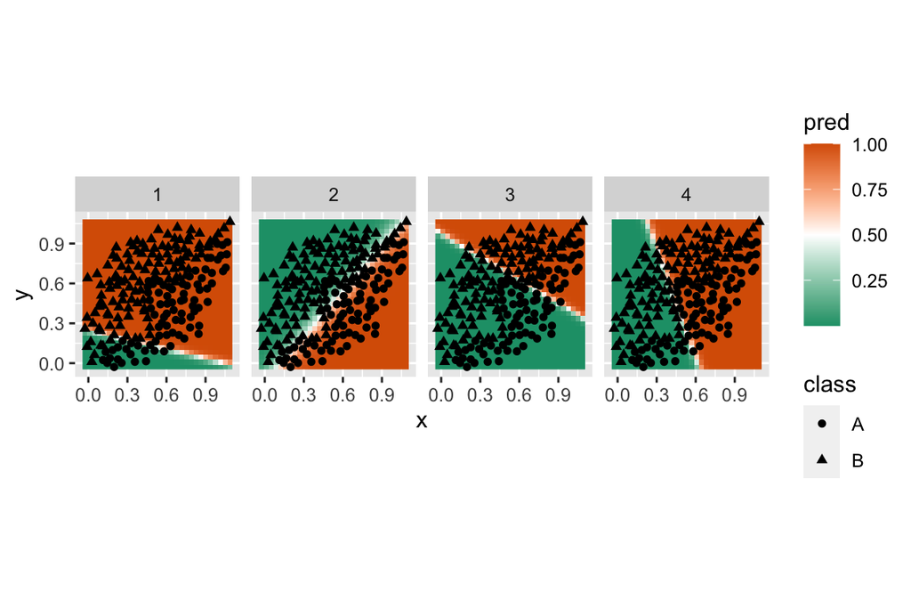

**We can see that each captures one linear aspect, of the nonlinear boundary.**

```
(iii) How many parameters are there in this model? Check that your answer matches the number of values in the `wgts` element of the `nnet` component.
```

**p=2, s=4, so there are 3x4=12. s=4 and there are two levels of output, so 5x2=10. There are 22 parameters.**

```
(iv) Write down the equation corresponding to the model at first node of the hidden layer. You need to look at the `wgts` element of the `nnet` component. There are 6 sets of linear model coefficients.
```

The coefficients are:

```
# [1] -19.01764  18.21640  77.10483
```

$$s_1 = 1/(1+e^{-(-19.01764+18.21640x+77.10483y)})$$
(v) OPTIONAL ADVANCED: See if you can compute the combination of the prediction on each hidden node, to get final prediction.

3. Read in the complete set of models fitted. There were 600 models fitted, 200 random starts for each $s = 2, 3, 4$. The `nnet` function has its own measure of the goodness of fit, which is used to determine when to stop minimising RSS, which is called `value` in this data. Plot the predictive accuracy against function’s returned value of model fit. Explain how the change in $s$ affects the predictive accuracy.

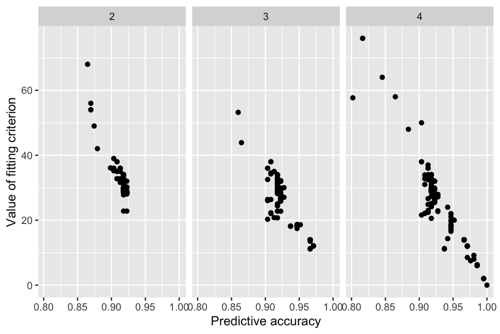

**The best performance is achieved by the 4 node models. The predictive accuracy matches fairly closely the fitting criteria. The biggest feature to note, though, is that there is a lot of variability across models. A different random start can generate a very poor model. It takes some work to find the bext model. But it can be a very good model.**

## 2.

1. Based on the lecture notes, explain whether the keras model can or can’t be applied to the paintings data from the past labs.
2. Fit the keras model to the handwritten digit data, following the code in the lecture notes. Read section 13.7 of https://bradleyboehmke.github.io/HOML/deep-learning.html#why-dl. Change your fitting code to use:
   1. change the number of nodes in each hidden layer, like Table 13.1 small and medium
   2. 2 hidden layer only (as well as the 1 layer from notes)
   3. add a batch normalisation step
   4. add a regularisation component to each layer
   5. try fitting the model with just 100 images, instead of 60000.

Examine the validation error vs the training error, like the plots in the chapter to compare the results for each of the changes in model structure.

**You are likely to find that changing the number of nodes, and the number of hidden layers, can dramatically change the validation error, in not all good ways. The regularisation step should help stablise the validation error, despite different choices of nodes and layers. Using 100 images only should not run.**